# Time series theory (2/2): R and Python

This notebook presents the foundational models in time-series beyond the random walk: **autoregressive** and **moving-average** processes.

# 1 Getting started (packages)

This notebook provides both R & Python code. The language tabs are synchronized throughout the document. Both languages execute from top to bottom (imperatively sequentially).

Quarto uses **knitr** and **reticulate** to execute both languages. Install any missing R packages from the list below, including reticulate (1.41 or later). The loading chunk declares Python dependencies, including the Excel reader, for reticulate’s managed environment.

For an existing Python installation, use `python -m pip install numpy pandas matplotlib seaborn scipy statsmodels requests openpyxl yfinance plotly`. Render with `quarto render 3_theory_2_R_Python.qmd`. Both languages use seed 42, but their random generators produce different samples.

**R**

```r
library(tidyverse)  # THE library for data science
library(openxlsx)   # A cool package to deal with Excel files/formats
library(quantmod)   # Package for financial data extraction
library(tsibble)    # TS with dataframes framework
library(fable)      # Package for time-series models & predictions
library(feasts)     # Package for time-series analysis
library(forecast)   # Another package for TS (forecasting)
library(tseries)    # Simple package for time-series tests
library(plotly)     # For 3D graphs
library(mvtnorm)    # For multivariate Gaussian distributions
library(crypto2)    # For cryto data
library(ggsci)      # For color palettes
reticulate::py_require(c(
  "numpy", "pandas", "matplotlib", "seaborn", "scipy", "statsmodels",
  "requests", "openpyxl>=3.1.5", "yfinance", "plotly"
))
set.seed(42)        # Random seed
```

**Python**

```python
import numpy as np
import pandas as pd
import matplotlib.pyplot as plt
import seaborn as sns
import requests
import yfinance as yf
import plotly.express as px
import statsmodels.api as sm
from statsmodels.graphics.tsaplots import plot_acf
from statsmodels.tsa.stattools import acf
from statsmodels.tsa.arima_process import arma_generate_sample
from statsmodels.tsa.ar_model import ar_select_order
from statsmodels.tsa.arima.model import ARIMA

rng = np.random.default_rng(42)
sns.set_theme(style="whitegrid")
```

# 2 The auto-regressive model

## 2.1 Introduction

**NoteDefinition**

Let us introduce a small yet crucial modification to the **random walk** process and consider:
$$x_t=a+\rho x_{t-1}+e_t, \quad a \in \mathbb{R}, \quad |\rho|< 1.$$
This process is called the **Auto-Regressive model** of order one and is written AR(1).

Iterating, we have:
$$x_t = a + \rho (a + \rho x_{t-2}+e_{t-1})+e_{t}$$
and, until infinity…
$$x_t=a \sum_{k=0}^\infty\rho^k+ \sum_{k=0}^\infty \rho^ke_{t-k}=\frac{a}{1-\rho}+ \sum_{k=0}^\infty \rho^ke_{t-k},$$
which explains why we need $|\rho|<1$ (if not, the process **explodes** asymptotically).

## 2.2 Interpretation

The process’ current value is determined by past values plus a contemporary shock.

This makes AR(p) processes useful to model variables that evolve gradually, such as:

- GDP
- Inflation
- Interest rates
- Temperature
- Asset **prices**.

In the AR(p) model, because of the **memory**, shocks can have a lasting effect. The higher the $\rho$ parameter, the longer the memory.

## 2.3 Properties

**NoteBasic properties**

We have
$$\mathbb{E}[x_t]=\frac{a}{1-\rho},$$
and when innovations are independent,
$$\mathbb{V}[x_t]=\mathbb{V}\left[\sum_{k=0}^\infty \rho^ke_{t-k} \right]=\sum_{k=0}^\infty \mathbb{V}\left[\rho^ke_{t-k} \right]=\frac{\sigma^2}{1-\rho^2}.$$

In this case, we see that the **mean** and **variance** do not depend on $t$! (obvious given the infinite series).

Moreover,

$$\mathbb{C}ov[x_t,x_{t+h}]=\mathbb{C}ov\left[\sum_{k=0}^\infty \rho^ke_{t-k} ,\sum_{j=0}^\infty \rho^je_{t-j+h} \right]=\sum_{k=0}^\infty \sum_{j=0}^\infty \mathbb{C}ov\left[ \rho^ke_{t-k}, \rho^je_{t-j+h} \right].$$
Again, we need to focus on the cases when the time indices are equal, so
$$\mathbb{C}ov[x_t,x_{t+h}]=\sum_{k=0}^\infty \sum_{j=h}^\infty \mathbb{C}ov\left[ \rho^ke_{t-k}, \rho^{j-h}e_{t-j} \right]=\sum_{k=0}^\infty \sum_{j=h}^\infty \rho^{k+j-h}\mathbb{C}ov[e_{t-k},e_{t-j} ].$$

Thus, for $j=k$, we get (mind the change in index, $m=j-h$)
$$\mathbb{C}ov[x_t,x_{t+h}]=\sigma^2 \sum_{j=h}^\infty \rho^{2j-h}=\sigma^2 \rho^{-h} \sum_{j=h}^\infty \rho^{2j}=\sigma^2 \rho^h \sum_{m=0}^\infty \rho^{2m}=\sigma^2\frac{\rho^h}{1-\rho^2}.$$
Again, this does not depend on the time index $t$. If innovations are Gaussian, as Gaussian distributions are entirely defined by their first two moments, this means that the full (unconditional) distribution of the process is **invariant**. This very convenient property is called **stationarity**, and comes in various flavors (have a look on the net!). It is very suitable for analysis because now we know that the object that we study (the underlying distribution) is stable in time.

The above quantity, which measures the link between different realizations of the same variable (at different points in time) is very important. Often, the covariance is scaled by the variance to yield the **auto-correlation** of the process.

**Note**

Relatedly, there is the **auto-correlogram**, which is defined, for stationary series, as

$$\gamma(h)=\mathbb{C}orr[x_t,x_{t+h}].$$

The sample version is
$$\hat{\gamma}(k) = \frac{\sum_{t=1}^{n-k}(x_t - \bar{x})(x_{t+k} - \bar{x})}{\sum_{t=1}^{n}(x_t - \bar{x})^2}.$$

For the AR(1), $\gamma(h)=\rho^h$, a super simple form: as $h$ increases, the correlation decreases following a power pattern.

More generally, autoregressive models of higher orders (AR(p)) have memory that goes back further in time:

$$x_t=a+\sum_{k=1}^p\rho_k x_{t-k}+e_t, \quad a \in \mathbb{R},$$

The average of the process is
$$\mathbb{E}[x_t]=\frac{a}{1-\rho_1-\dots-\rho_p}.$$

This of course imposes a restriction on the coefficients…  
However, there is no simple expression for the variance…

## 2.4 Illustration (simulations)

Let’s simulate two such processes. We refer to the [ARIMA](https://stat.ethz.ch/R-manual/R-devel/library/stats/html/arima.html) page for details on the implementation. The order is $(p,d,q)$, like in the ARMA(p,q) process (the $d$ is for integration, a notion out of the scope of this course, simply linked to the fact that the model can be differentiated if need be).

**R**

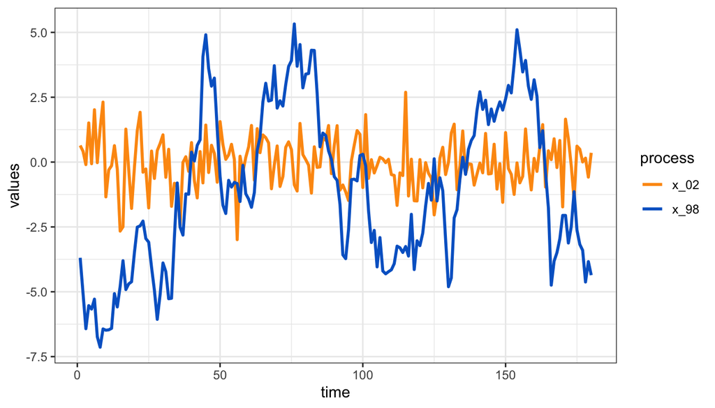

```r
N <- 180
x_02 <- arima.sim(list(order = c(1,0,0), ar=.02), n = N)
x_98 <- arima.sim(list(order = c(1,0,0), ar=.98), n = N)
tibble(time = 1:N, x_02 = x_02, x_98 = x_98) |>
  pivot_longer(-time, names_to = "process", values_to = "values") |>
  ggplot(aes(x = time, y = values, color = process)) + geom_line(linewidth = 1) +
  theme_bw() +
  scale_color_manual(values = c("#FD9911", "#0066CC"))
```

**Python**

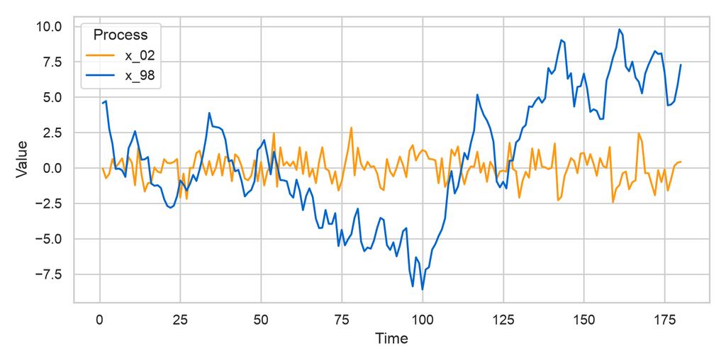

```python
N = 180
x_02 = arma_generate_sample([1, -0.02], [1], nsample=N,
                           burnin=1000, distrvs=rng.standard_normal)
x_98 = arma_generate_sample([1, -0.98], [1], nsample=N,
                           burnin=1000, distrvs=rng.standard_normal)
fig, ax = plt.subplots(figsize=(8, 4))
ax.plot(np.arange(1, N + 1), x_02, label="x_02", color="#FD9911")
ax.plot(np.arange(1, N + 1), x_98, label="x_98", color="#0066CC")
ax.set(xlabel="Time", ylabel="Value")
ax.legend(title="Process")
fig.tight_layout()
plt.show()
```

One of the processes seems to be just white noise, the other evolves more slowly and oscillates much less.

Let’s have a look at the auto-correlogram of the series. In **R**, ACF means AutoCorrelation Function.

**R**

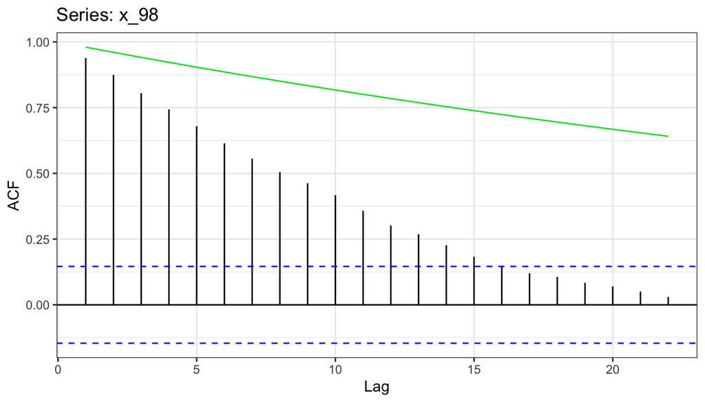

```r
ggAcf(x_98) + theme_bw() +
  geom_function(fun = function(x) 0.98^x, color = "#11DD33")
```

**Python**

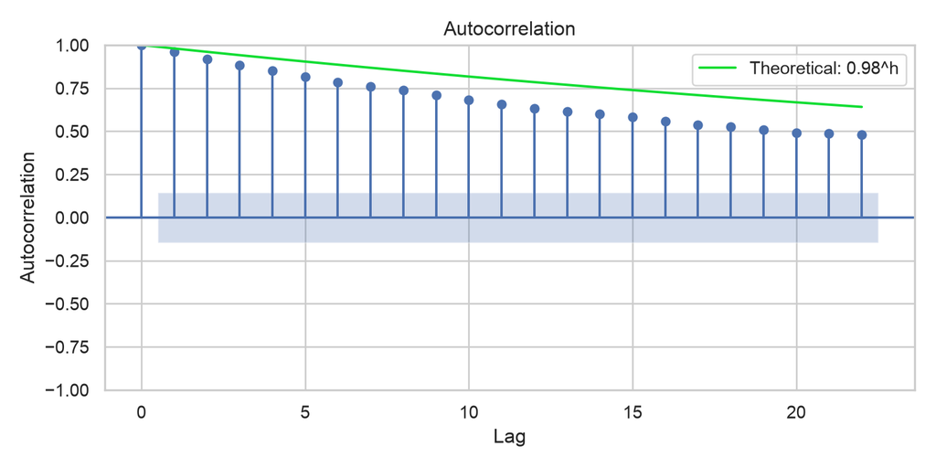

```python
acf_lags = int(np.floor(10 * np.log10(len(x_98))))
fig, ax = plt.subplots(figsize=(8, 4))
plot_acf(x_98, lags=acf_lags, bartlett_confint=False, ax=ax)
h = np.arange(acf_lags + 1)
ax.plot(h, 0.98 ** h, color="#11DD33", label="Theoretical: 0.98^h")
ax.set(xlabel="Lag", ylabel="Autocorrelation")
ax.legend()
fig.tight_layout()
plt.show()
```

The values we extract from the sample are not exactly those predicted from the model. This comes from size of the sample, which is too small. As it increases, we would obtain a perfect fit (you can try!).

# 3 Moving averages

## 3.1 Definitions

**NoteSimple moving average**

The SMA, in its backward-looking version:
$$\text{MA}_t(X,N) = \frac{1}{N} \sum_{n=1}^N X_{t+1-n} .$$

But maybe some observations matter more than others.

**NoteExponentially-weighted moving average**

The EWMA, backward-looking:
$$\text{EWMA}_t(X, \alpha) = (1-\alpha) \sum_{n=0}^\infty \alpha^n X_{t-n}, \quad \alpha \in (0,1).$$
This gives more weight to the most recent observations. The scaling factor comes from $\sum_{n=0}^\infty \alpha^n=(1-\alpha)^{-1}$.

The averages can also be forward-looking (with knowledge of the future):
$$\text{MA}^{\text{fwd}}_t(X,N) = \frac{1}{N} \sum_{n=1}^N X_{t-1+n}.$$

Or sometimes they can even be **centered** (taking $N/2$ before and $N/2$ after). This depends on the context.

**Updating** is very easy for the EWMA (based on the previous value of EWMA):

$$\text{EWMA}_t(X, \alpha) = \alpha \text{EWMA}_{t-1}(X, \alpha) + (1-\alpha) X_t .$$

For the simple MA, it is:

$$\text{MA}_{t+1} = \text{MA}_{t} + \frac{1}{m}\left( X_{t+1} - X_{t-m+1} \right).$$

## 3.2 Examples

**R**

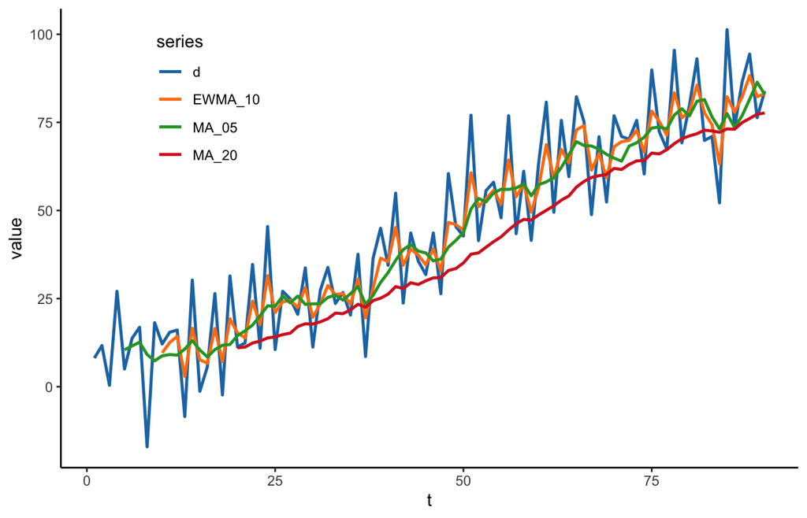

```r
t <- 1:90
d <- t + 10*sin(t*10) + 10*rnorm(length(t))
MA_05 <- SMA(d, 5)
EWMA_10 <- EMA(d, 10, ratio = 0.5)
MA_20 <- SMA(d, 20)
data.frame(t, d, MA_05, EWMA_10, MA_20) |>
  pivot_longer(-t, values_to = "value", names_to = "series") |>
  ggplot(aes(x = t, y = value, color = series)) + geom_line(linewidth = 0.9) +
  theme_classic() +
  theme(legend.position = c(0.2,0.8)) +
  scale_color_d3()
```

**Python**

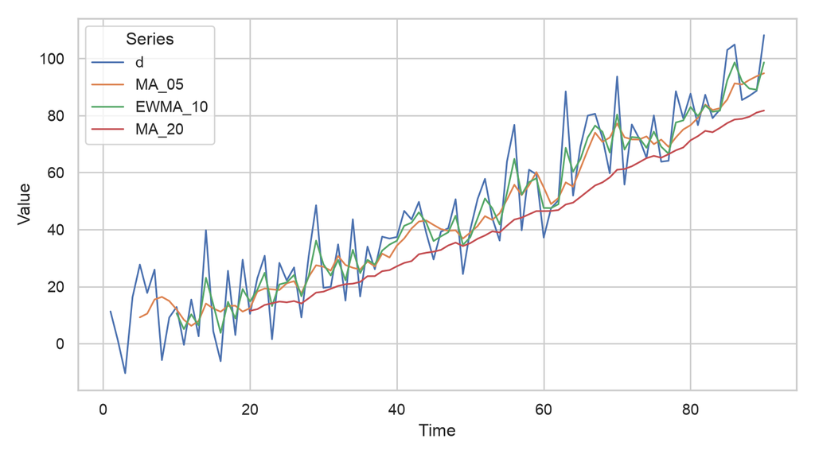

```python
t = np.arange(1, 91)
d = pd.Series(t + 10 * np.sin(t * 10) + 10 * rng.normal(size=len(t)))
MA_05 = d.rolling(5).mean()
MA_20 = d.rolling(20).mean()
# TTR::EMA starts with the mean of the first 10 observations.
EWMA_10 = pd.Series(np.nan, index=d.index)
EWMA_10.iloc[9] = d.iloc[:10].mean()
for i in range(10, len(d)):
    EWMA_10.iloc[i] = 0.5 * d.iloc[i] + 0.5 * EWMA_10.iloc[i - 1]
ma_examples = pd.DataFrame({"d": d, "MA_05": MA_05,
                            "EWMA_10": EWMA_10, "MA_20": MA_20}, index=d.index)
ax = ma_examples.set_axis(t).plot(figsize=(8, 4.5), linewidth=1.2)
ax.set(xlabel="Time", ylabel="Value")
ax.legend(title="Series")
plt.tight_layout()
plt.show()
```

Note that when $N$ is large, the averaging takes some time (i.e., points) and the MA starts later in the sample…

# 4 The MA(q)-process

## 4.1 Introduction

**NoteDefinition**

A **Moving Average** process of order $q$, denoted MA($q$), models a univariate time series $\{x_t\}$ as a linear function of current and past error terms:

$$x_t = \mu + e_t + \theta_1 e_{t-1} + \theta_2 e_{t-2} + \cdots + \theta_q e_{t-q},$$

where:

- $\mu$ is the mean of the process,
- $e_t$ is a white-noise innovation with variance $\sigma_e^2$,
- $\theta_1, \theta_2, \dots, \theta_q$ are MA coefficients.

The innovations are assumed to satisfy:
$$e_t \sim (0, \sigma_e^2), \qquad \text{i.i.d.},$$

with:
$$\mathbb{E}[e_t e_{t-s}] =
\begin{cases}
\sigma_e^2, & s = 0, \\
0, & s \neq 0.
\end{cases}$$

$$\operatorname{Cov}(x_t,x_{t+h})=\sigma_e^2\sum_{s=0}^{q-h}\theta_s\theta_{s+h}, \quad 0\leq h\leq q,\quad \theta_0=1$$

Hence, nonzero terms are those for which $t-s=t+h-r$, i.e., $s = r-h$.

In short, the **autocovariance function** of an MA($q$) process is nonzero only up to lag $q$:

$$\gamma(s) =
\begin{cases}
\sigma_e^2 \left( 1 + \theta_1^2 + \cdots + \theta_q^2 \right), & s = 0, \\[6pt]
\sigma_e^2 \left( \theta_s + \theta_1 \theta_{s+1} + \cdots + \theta_{q-s} \theta_q \right), & 1 \le s \le q, \\[6pt]
0, & s > q.
\end{cases}$$

Thus, the MA($q$) process has a finite autocorrelation structure. After a time that is beyond the maximum lag, there is no more (auto-)**correlation**.

## 4.2 Interpretation

The series is driven entirely by shocks. In an MA(q) process, the value of the time series at time $t$ ($x_t$) is a weighted sum of current and past shocks. These shocks have temporary (not persistent) effects; after some time, they are “forgotten”. Hence, MA models have **short memory**.

They are useful when:

- The series reacts sharply to random events (especially true in finance);
- The effect dissipates quickly;
- The autocorrelation function drops to zero after a few lags.

## 4.3 Simulation

We can either build the series manually (interesting intellectually)…

**R**

```r
simulate_ma <- function(n, theta, sigma = 1) {
  q <- length(theta)
  epsilon <- rnorm(n + q, mean = 0, sd = sigma)
  y <- numeric(n)
  for (t in 1:n) {
    y[t] <- epsilon[t + q] + sum(theta * epsilon[(t + q - 1):(t)])
  }
  return(y)
}
ma_series_1 <- simulate_ma(n = N, theta = c(0.6, -0.4), sigma = 1)
```

**Python**

```python
def simulate_ma(n, theta, sigma=1):
    q = len(theta)
    epsilon = rng.normal(scale=sigma, size=n + q)
    y = np.empty(n)
    for t in range(n):
        past_shocks = epsilon[t:t + q][::-1]
        y[t] = epsilon[t + q] + np.dot(theta, past_shocks)
    return y

ma_series_1 = simulate_ma(n=N, theta=[0.6, -0.4], sigma=1)
```

or resort on the R internal function…

**R**

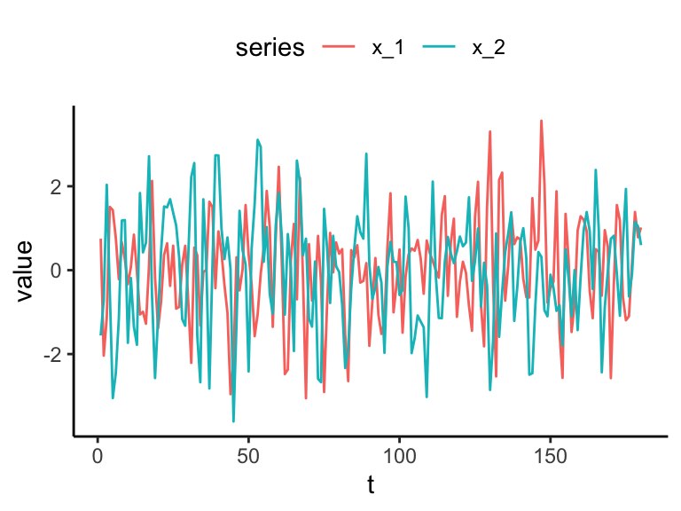

```r
ma_series_2 <- arima.sim(model = list(ma = c(0.6, -0.4)), n = N)
data.frame(t = 1:N, x_1 = ma_series_1, x_2 = ma_series_2) |>
  pivot_longer(-t, names_to = "series", values_to = "value") |>
  ggplot(aes(x = t, y = value, color = series)) + geom_line() +
  theme_classic() +
  theme(legend.position = "top")
```

**Python**

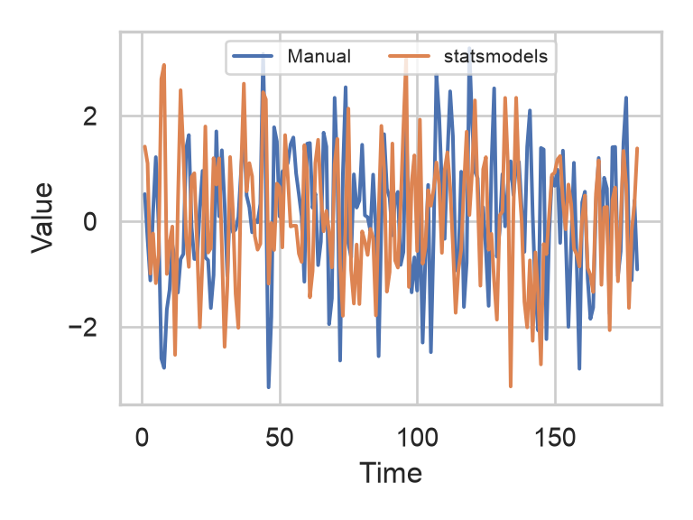

```python
ma_series_2 = arma_generate_sample([1], [1, 0.6, -0.4], nsample=N,
                                 burnin=100, distrvs=rng.standard_normal)
fig, ax = plt.subplots(figsize=(4, 3))
ax.plot(np.arange(1, N + 1), ma_series_1, label="Manual")
ax.plot(np.arange(1, N + 1), ma_series_2, label="statsmodels")
ax.set(xlabel="Time", ylabel="Value")
ax.legend(loc="upper center", ncol=2, fontsize=8)
fig.tight_layout()
plt.show()
```

The series seem similar indeed

## 4.4 Reading the ACF and PACF

The ACF measures the correlation between observations at each lag. The **partial autocorrelation function** (PACF) removes the linear contribution of the intervening lags. At lag two, for example, it measures the link between $x_t$ and $x_{t-2}$ after accounting for $x_{t-1}$.

Compare these two processes, with independent standard Gaussian shocks:

$$\underbrace{X_t=0.7X_{t-1}+e_t}_{\mathrm{AR}(1)},
\qquad
\underbrace{Y_t=u_t+0.7u_{t-1}}_{\mathrm{MA}(1)}.
\tag{1}$$

For the AR(1), the ACF decays with the lag, while the PACF is zero after lag one. For the MA(1), the ACF is zero after lag one, while the PACF decays.

**R**

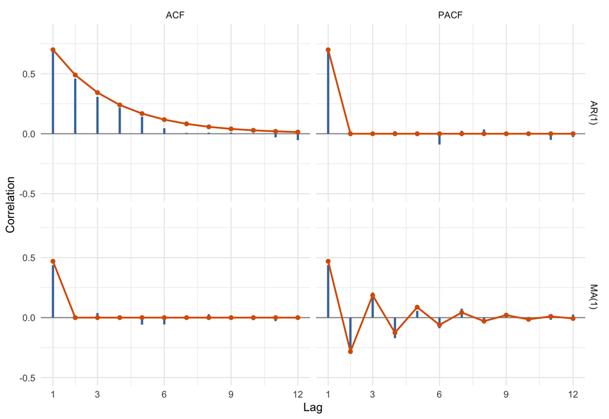

Bars show sample correlations; orange lines show the model values. Each series contains 800 observations.

```r
withr::with_seed(42, {
  comparison_models <- list(`AR(1)` = list(ar = 0.7),
                            `MA(1)` = list(ma = 0.7))
  correlation_comparison <- map_dfr(names(comparison_models), function(model) {
    specification <- comparison_models[[model]]
    values <- arima.sim(model = specification, n = 800)
    tibble(
      model = model,
      lag = rep(1:12, 2),
      measure = rep(c("ACF", "PACF"), each = 12),
      sample = c(as.numeric(acf(values, lag.max = 12, plot = FALSE)$acf)[-1],
                 as.numeric(pacf(values, lag.max = 12, plot = FALSE)$acf)),
      theory = c(do.call(ARMAacf, c(specification, list(lag.max = 12)))[-1],
                 do.call(ARMAacf, c(specification, list(lag.max = 12, pacf = TRUE)))))
  }) |>
    mutate(measure = factor(measure, levels = c("ACF", "PACF")))

  print(ggplot(correlation_comparison, aes(lag, sample)) +
    geom_hline(yintercept = 0, color = "gray60") +
    geom_segment(aes(xend = lag, yend = 0), color = "#4477AA", linewidth = 1) +
    geom_line(aes(y = theory), color = "#D95F02", linewidth = 0.8) +
    geom_point(aes(y = theory), color = "#D95F02", size = 1.5) +
    facet_grid(model ~ measure) +
    scale_x_continuous(breaks = c(1, 3, 6, 9, 12)) +
    coord_cartesian(ylim = c(-0.5, 0.85)) +
    labs(x = "Lag", y = "Correlation") + theme_minimal())
})
```

**Python**

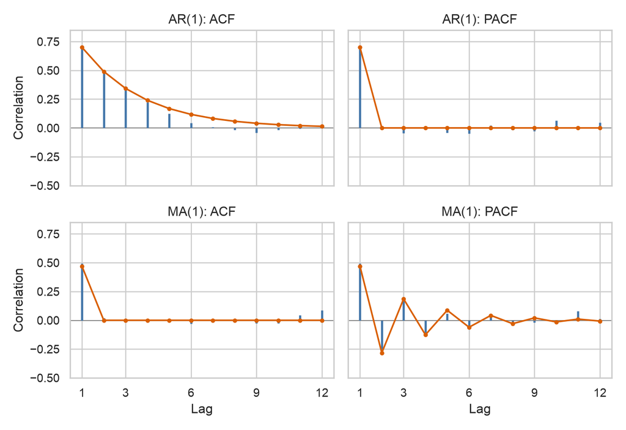

Bars show sample correlations; orange lines show the model values. Each series contains 800 observations.

```python
from statsmodels.tsa.arima_process import ArmaProcess
from statsmodels.tsa.stattools import pacf

comparison_rng = np.random.default_rng(42)
comparison_models = [("AR(1)", ArmaProcess([1, -0.7], [1])),
                     ("MA(1)", ArmaProcess([1], [1, 0.7]))]
comparison_lags = np.arange(1, 13)
fig, axes = plt.subplots(2, 2, figsize=(8, 5.5), sharex=True, sharey=True)
for row, (name, process) in enumerate(comparison_models):
    values = process.generate_sample(nsample=800, burnin=1000,
                                     distrvs=comparison_rng.standard_normal)
    sample_correlations = [acf(values, nlags=12, fft=True)[1:],
                           pacf(values, nlags=12, method="ywm")[1:]]
    model_correlations = [process.acf(lags=13)[1:], process.pacf(lags=13)[1:]]
    for col, measure in enumerate(["ACF", "PACF"]):
        ax = axes[row, col]
        ax.axhline(0, color="gray", linewidth=0.7)
        ax.vlines(comparison_lags, 0, sample_correlations[col], color="#4477AA", linewidth=2)
        ax.plot(comparison_lags, model_correlations[col], "o-", color="#D95F02", markersize=3)
        ax.set(title=f"{name}: {measure}", ylim=(-0.5, 0.85), xticks=[1, 3, 6, 9, 12])
for ax in axes[1]:
    ax.set_xlabel("Lag")
for ax in axes[:, 0]:
    ax.set_ylabel("Correlation")
fig.tight_layout()
plt.show()
```

For an AR($p$), the population PACF is zero beyond lag $p$; for an MA($q$), the population ACF is zero beyond lag $q$. Sample correlations fluctuate around these patterns, so look across several lags when choosing orders to try.

# 5 The ARMA(p,q) process

Basically, it’s a combination of AR(p) and MA(q)!

An Autoregressive Moving Average process of order $(p, q)$, denoted ARMA($p, q$), combines both autoregressive and moving average components. It is defined as:

$$\begin{align}
x_t &= c + \phi_1 x_{t-1} + \phi_2 x_{t-2} + \cdots + \phi_p x_{t-p} + e_t
+ \theta_1 e_{t-1} + \theta_2 e_{t-2} + \cdots + \theta_q e_{t-q} \\
&= c + \sum_{i=1}^{p} \phi_i\, x_{t-i} + e_t + \sum_{j=1}^{q} \theta_j\, e_{t-j}.
\end{align}$$

where:

- $x_t$ is the value of the time series at time $t$;
- $c$ is a constant term;
- $\phi_1, \dots, \phi_p$ are autoregressive coefficients;
- $\theta_1, \dots, \theta_q$ are moving average coefficients;
- $e_t$ is a white-noise innovation with variance $\sigma_e^2$.

The innovations satisfy $e_t \sim (0, \sigma_u^2), \qquad \text{i.i.d.}$, with
$$\mathbb{E}[e_t e_{t-s}] =
\begin{cases}
\sigma_e^2, & s = 0, \\
0, & s \neq 0.
\end{cases}$$

**NoteCompact lag-operator representation**

Using the lag operator $L x_t = x_{t-1}$, an ARMA($p, q$) process can be written as:

$$\phi(L) x_t = c + \theta(L) e_t,$$

with $\phi(L) = 1 - \phi_1 L - \phi_2 L^2 - \cdots - \phi_p L^p,$ and $\theta(L) = 1 + \theta_1 L + \theta_2 L^2 + \cdots + \theta_q L^q.$

In particular, when $p=q=1$…

**NoteThe properties of the ARMA(1,1) are as follows:**

$$\begin{align}
\mathbb{E}[x_t]&=\frac{c}{1-\phi}, \\
\mathbb{V}[x_t]&=
\frac{(1+\theta^2 + 2\phi\theta)\,\sigma^2}
{1 - \phi^2}, \\
\operatorname{Corr}(x_t,x_{t+1})&= \frac{(\phi + \theta)(1 + \phi\theta)}{1 + 2\phi\theta + \theta^2}
\end{align}$$
For longer lags, multiply the lag-one correlation by $\phi^{h-1}$, for $h\geq1$.

# 6 Predictive regressions

## 6.1 Introduction

PRs are somewhat out of the scope of time-series strictly speaking because they seek to forecast variables with **other** variables.  
Namely, the simplest formulation is the following.

**NoteDefinition**

A (simple) **predictive regression** can be written as
$$y_{t+1} = a+ bx_t + e_{t+1},$$
where the error terms $e_t$ satisfy the usual assumptions (iid white noise, etc.).

More general models are written

$$y_{t+k} = a+X_{t}B + e_t,$$
where the difference is in the lag $k$ and in the fact that there can be more than one **predictor** $X$.

In inference, several problems can arise when, for instance $x_t$ is itself auto-correlated. For a modern take on this issue, we refer to [Biases in long-horizon predictive regressions](https://www.sciencedirect.com/science/article/abs/pii/S0304405X21004013).

## 6.2 In practice

1. We estimate the model on past data, either with a simple OLS estimator $\hat{B}=(X_T'X_T)^{-1}X_T'y_{T+k}$.
2. We make a prediction with the current value of $x_t$: $\tilde{y}_{t+k}=X_t\hat{B}$.
3. Evaluate the error (requires the realization of $y_{t+k}$).

# 7 Application to cryptocurrencies

For simplicity, we will work with **daily** data. Higher frequencies can be obtained outside the crypto space via the [highfrequency package](https://cran.r-project.org/web/packages/highfrequency/index.html). Or playing with dedicated APIs (e.g. with packages: [binance](https://cran.r-project.org/web/packages/binancer/index.html)/[coinmarketcap](https://cran.r-project.org/web/packages/coinmarketcapr/readme/README.html)).

## 7.1 Fetching data

The R examples use `crypto2` and CoinMarketCap. Python uses [CoinGecko](https://docs.coingecko.com/reference/coins-list) for coin information and [Yahoo Finance](https://ranaroussi.github.io/yfinance/reference/api/yfinance.download.html) for daily USD prices. The download snippets below illustrate each provider’s interface. The worked application uses the same saved CoinMarketCap prices in both languages.

First, let’s have a look at the list of available coins… which are numerous!

**R**

```r
coins <- crypto_list()
```

**Python**

```python
response = requests.get("https://api.coingecko.com/api/v3/coins/list", timeout=120)
response.raise_for_status()
coins = pd.DataFrame(response.json())
print(coins.head())
```

```
                                       id  ...                              name
0                                       _  ...                        ༼ つ ◕_◕ ༽つ
1                             000-capital  ...                       000 Capital
2  01111010011110000110001001110100-token  ...  01111010011110000110001001110100
3  01112131415161718192021222324252-token  ...  01112131415161718192021222324252
4                                01-token  ...                                01

[5 rows x 3 columns]
```

You can have a look at the info for the coins via the commented code below.

**R**

```r
c_info <- crypto_info(coin_list = coins, limit = 30)
```

```
❯ Scraping crypto info
```

```
❯ Processing crypto info
```

**Python**

```python
response = requests.get(
    "https://api.coingecko.com/api/v3/coins/markets",
    params={"vs_currency": "usd", "order": "market_cap_desc",
            "per_page": 30, "page": 1}, timeout=120)
response.raise_for_status()
c_info = pd.DataFrame(response.json())
print(c_info[["id", "symbol", "name", "current_price", "market_cap"]].head())
```

```
            id symbol      name  current_price     market_cap
0      bitcoin    btc   Bitcoin   65875.000000  1324859861827
1     ethereum    eth  Ethereum    1848.980000   225980095229
2       tether   usdt    Tether       0.999379   175289001958
3  binancecoin    bnb       BNB     598.850000    78755097044
4     usd-coin   usdc      USDC       0.999655    69053805886
```

The next snippets show how to download historical quotes and are not executed during rendering. The worked examples load the saved sample immediately afterward.

**R**

```r
coin_names <- c("Bitcoin", "Ethereum", "Tether USDt", "BNB", "Solana")
coin_hist <- crypto_history(coins |> dplyr::filter(name %in% coin_names),
                            start_date = "20170101",
                            end_date = "20261206")
coin_hist <- coin_hist |>  # Timestamps are at midnight, hence we add a day.
  dplyr::mutate(date = 1 + as.Date(as.POSIXct(timestamp, origin="1970-01-01")))
```

**Python**

```python
coin_tickers = {"BTC-USD": ("bitcoin", "Bitcoin", "BTC"),
                "ETH-USD": ("ethereum", "Ethereum", "ETH"),
                "USDT-USD": ("tether", "Tether USDt", "USDT"),
                "BNB-USD": ("bnb", "BNB", "BNB"),
                "SOL-USD": ("solana", "Solana", "SOL")}
quotes = yf.download(list(coin_tickers), start="2017-01-01", end="2026-12-07",
                     auto_adjust=False, progress=False)
closes = quotes["Close"].reindex(columns=list(coin_tickers))
if closes.empty or closes.isna().all().any():
    raise ValueError("Yahoo Finance returned no prices for one or more coins.")
closes.index.name = "timestamp"
coin_hist = (closes.reset_index()
             .melt(id_vars="timestamp", var_name="ticker", value_name="close")
             .dropna(subset=["close"]))
coin_hist["slug"] = coin_hist["ticker"].map(lambda k: coin_tickers[k][0])
coin_hist["name"] = coin_hist["ticker"].map(lambda k: coin_tickers[k][1])
coin_hist["symbol"] = coin_hist["ticker"].map(lambda k: coin_tickers[k][2])
coin_hist["timestamp"] = pd.to_datetime(coin_hist["timestamp"]).dt.tz_localize(None)
coin_hist["date"] = coin_hist["timestamp"]
coin_hist = coin_hist.sort_values(["name", "timestamp"]).reset_index(drop=True)
print(coin_hist.head())
```

**R**

```r
coin_hist <- read_csv("data/3_theory_2_crypto_prices.csv",
                      col_types = cols(timestamp = col_date(), date = col_date())) |>
  mutate(timestamp = as.POSIXct(timestamp, tz = "UTC"))
head(coin_hist)
```

```
# A tibble: 6 × 6
  timestamp           date       slug    name    symbol close
  <dttm>              <date>     <chr>   <chr>   <chr>  <dbl>
1 2017-01-01 00:00:00 2017-01-01 bitcoin Bitcoin BTC     998.
2 2017-01-02 00:00:00 2017-01-02 bitcoin Bitcoin BTC    1022.
3 2017-01-03 00:00:00 2017-01-03 bitcoin Bitcoin BTC    1044.
4 2017-01-04 00:00:00 2017-01-04 bitcoin Bitcoin BTC    1155.
5 2017-01-05 00:00:00 2017-01-05 bitcoin Bitcoin BTC    1013.
6 2017-01-06 00:00:00 2017-01-06 bitcoin Bitcoin BTC     902.
```

**Python**

```python
coin_hist = pd.read_csv("data/3_theory_2_crypto_prices.csv",
                        parse_dates=["timestamp", "date"])
print(coin_hist.head())
```

```
   timestamp       date     slug     name symbol        close
0 2017-01-01 2017-01-01  bitcoin  Bitcoin    BTC   998.325012
1 2017-01-02 2017-01-02  bitcoin  Bitcoin    BTC  1021.750000
2 2017-01-03 2017-01-03  bitcoin  Bitcoin    BTC  1043.839966
3 2017-01-04 2017-01-04  bitcoin  Bitcoin    BTC  1154.729980
4 2017-01-05 2017-01-05  bitcoin  Bitcoin    BTC  1013.380005
```

And plot them. **NOTE**: mind the log-scale for the *y*-axis.  
Also, we use [**plotly**](https://plotly.com/graphing-libraries/) below for a better experience.

**R**

```r
library(plotly)
g <- coin_hist |>
  ggplot(aes(x = date, y = close, color = name, label = symbol)) +
  geom_line() +
  scale_y_log10() + theme_bw() + xlab("")
ggplotly(g)
```

[interactive chart not shown]

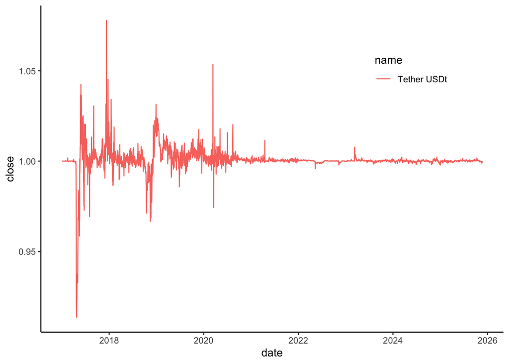

```r
coin_hist |>
  filter(symbol %in% c("USDT")) |>
  ggplot(aes(x = date, y = close, color = name, label = symbol)) +
  geom_line() + theme_classic() +
  theme(legend.position = c(0.8,0.8))
```

**Python**

```python
fig = px.line(coin_hist, x="date", y="close", color="name",
              hover_data=["symbol"], log_y=True,
              labels={"date": "", "close": "USD closing price"})
fig.update_layout(height=420);
fig
```

[interactive chart not shown]

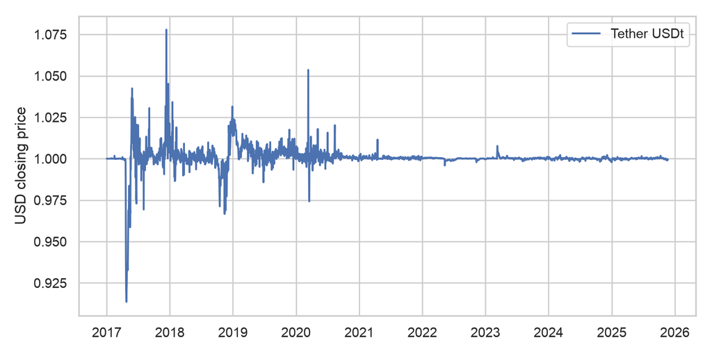

```python
usdt = coin_hist.loc[coin_hist["symbol"].eq("USDT")]
fig_usdt, ax = plt.subplots(figsize=(8, 4))
ax.plot(usdt["date"], usdt["close"], label="Tether USDt")
ax.set(xlabel="", ylabel="USD closing price")
ax.legend()
fig_usdt.tight_layout()
plt.show()
```

Now, the problem with some of these series is that they are **NOT** stationary. At the beginning of the sample, their values are much lower to those at th end of the sample. This is one of the reasons why in finance, we look at **returns**:
$$r_t=\frac{p_t-p_{t-1}}{p_{t-1}},$$
which are simply relative price changes.
Let’s compute them below. We recall that prices are gathered in the **close** column.

**R**

```r
coin_hist <- coin_hist |>
  arrange(name, timestamp) |>
  group_by(name) |>
  mutate(return = close / lag(close) - 1 ) |>
  ungroup()
```

**Python**

```python
coin_hist = coin_hist.sort_values(["name", "timestamp"])
coin_hist["return"] = coin_hist.groupby("name")["close"].pct_change(fill_method=None)
```

And have a look at their distributions.

**R**

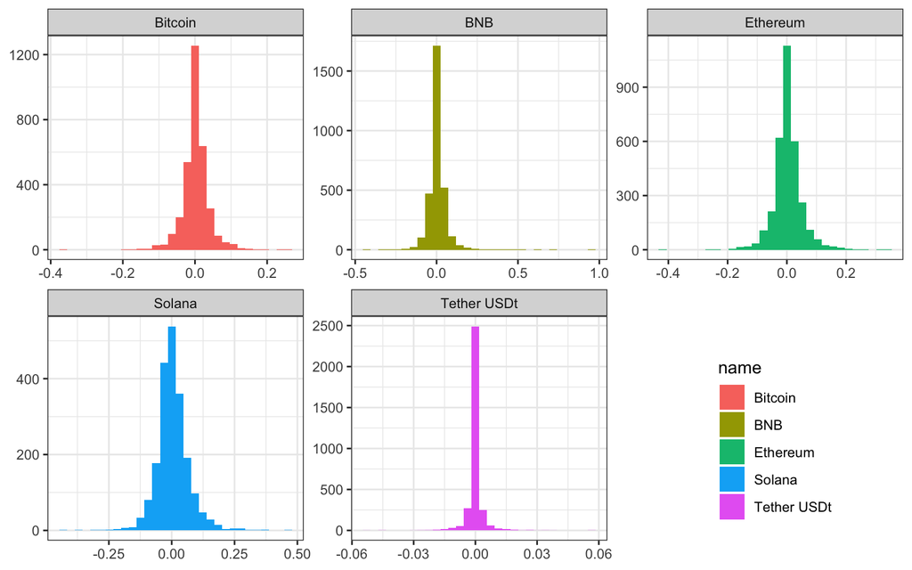

```r
coin_hist |>
  ggplot(aes(x = return, fill = name)) + geom_histogram() +
  facet_wrap(vars(name), scales = "free") + theme_bw() +
  theme(axis.title = element_blank(),
        legend.position = c(0.85,0.2))
```

**Python**

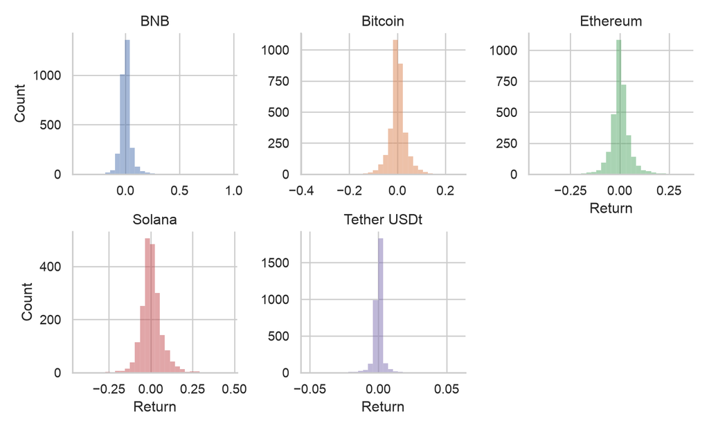

```python
g = sns.displot(data=coin_hist.dropna(subset=["return"]), x="return", hue="name",
                col="name", col_wrap=3, bins=30, common_bins=False, facet_kws={"sharex": False,
                "sharey": False}, height=2.5, aspect=1.1, legend=False)
g.set_axis_labels("Return", "Count");
g.set_titles("{col_name}");
g.tight_layout();
plt.show()
```

Are these distributions Gaussian?

There seem to be **outliers** (far to the left or far to the right of the most common values)!

## 7.2 Returns

First, let’s have a look a autocorrelograms (of returns).

**R**

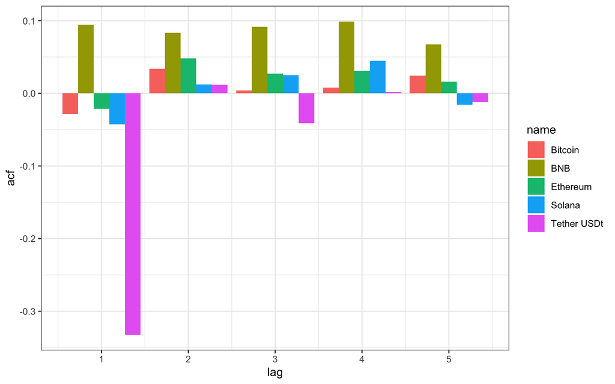

```r
crypto_acf <-
  coin_hist |>
  na.omit() %>%
  split(.$name) %>%
  map(~acf(.$return, plot = F)) %>%
  map_dfr(
    ~data.frame(lag = .$lag,
                acf = .$acf,
                ci = qnorm(0.975)/sqrt(.$n.used)
    ), .id = "name")
crypto_acf |>
  filter(lag > 0, lag < 6) |>
  ggplot(aes(x = lag, y = acf, fill = name)) +
  geom_col(position = "dodge") + theme_bw()
```

**Python**

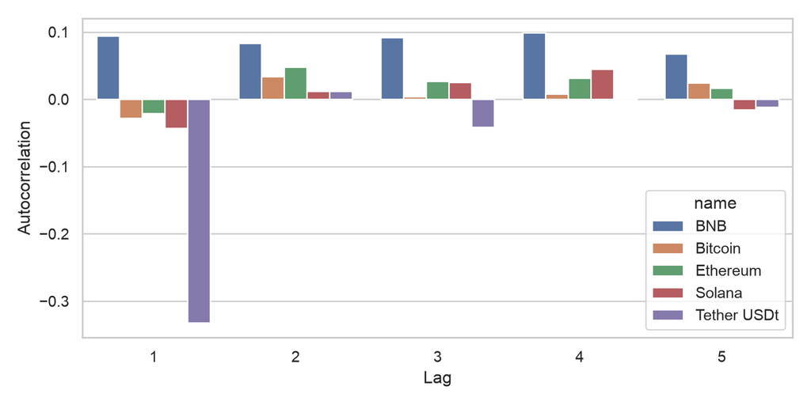

```python
crypto_acf = []
for name, group in coin_hist.groupby("name"):
    values = group["return"].dropna().to_numpy()
    coefficients = acf(values, nlags=5, fft=True, adjusted=False)
    crypto_acf.extend({"name": name, "lag": lag, "acf": coefficients[lag]}
                      for lag in range(1, 6))
crypto_acf = pd.DataFrame(crypto_acf)
fig, ax = plt.subplots(figsize=(8, 4))
sns.barplot(data=crypto_acf, x="lag", y="acf", hue="name", ax=ax)
ax.set(xlabel="Lag", ylabel="Autocorrelation")
fig.tight_layout()
plt.show()
```

But recall that some of the coins are **stable**!  
Overall, however, there does not seem to be a strong memory pattern.  
Hence, daily returns appear to be mostly **white noise**.

**R**

```r
coin_data <- coin_hist |>
  select(timestamp, slug, close) |>
  distinct() |>
  arrange(slug, timestamp) |>
  group_by(slug) |>
  mutate(return = close / lag(close) - 1) |>
  ungroup() |>
  pivot_wider(names_from = slug, values_from = c(close, return)) |>
  arrange(timestamp)
```

**Python**

```python
coin_data = (coin_hist.pivot(index="timestamp", columns="slug", values="close")
             .sort_index())
returns = coin_data.pct_change(fill_method=None)
coin_data = pd.concat([coin_data.add_prefix("close_"),
                       returns.add_prefix("return_")], axis=1).reset_index()
coin_data.columns.name = None
```

## 7.3 Estimations

### 7.3.1 AR(p)

Ok, so now let’s try to link what we have seen in the theoretical part with the data. This step is called **estimation**.  
Basically, if we think that the data follows $x_t=bx_{t-1}+e_t$, we need to find a good value for $b$ (the best possible)!  
Let’s have a look at the data again…

**R**

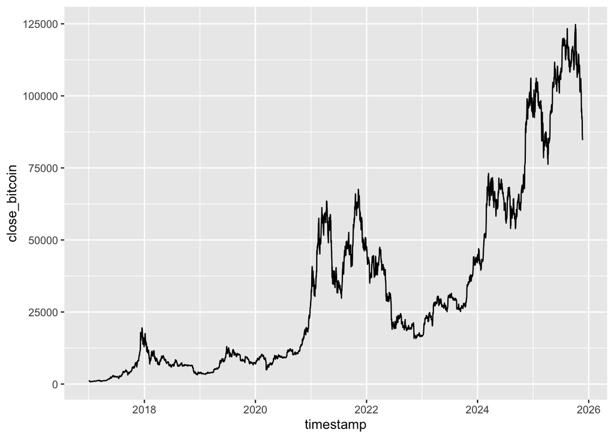

```r
coin_data |> ggplot(aes(x = timestamp, y = close_bitcoin)) + geom_line()
```

**Python**

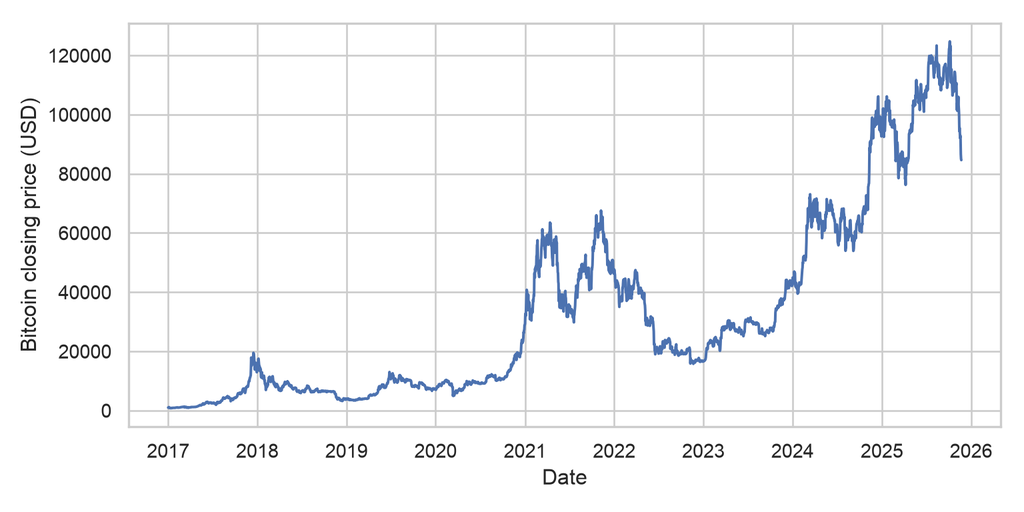

```python
fig, ax = plt.subplots(figsize=(8, 4))
ax.plot(coin_data["timestamp"], coin_data["close_bitcoin"])
ax.set(xlabel="Date", ylabel="Bitcoin closing price (USD)")
fig.tight_layout()
plt.show()
```

So this series is clearly not **stationary**. Hence we must resort to the relative differences (returns)…

**R**

```r
btc_return <- coin_data$return_bitcoin |> na.omit()
ar(btc_return)
```

```
Call:
ar(x = btc_return)

Coefficients:
      1        2
-0.0273   0.0329

Order selected 2  sigma^2 estimated as  0.001311
```

**Python**

```python
btc_return = coin_data["return_bitcoin"].dropna().reset_index(drop=True)
max_order = min(len(btc_return) - 1, int(np.floor(10 * np.log10(len(btc_return)))))
selected_ar = ar_select_order(btc_return, maxlag=max_order, ic="aic", trend="c")
ar_fit = selected_ar.model.fit()
print("Selected lags:", selected_ar.ar_lags)
```

```
Selected lags: [1, 2]
```

```python
print(ar_fit.params)
```

```
const                0.002005
return_bitcoin.L1   -0.027441
return_bitcoin.L2    0.032852
dtype: float64
```

Both examples select the lag order using AIC. R uses Yule–Walker estimation; Python uses least squares through [ar_select_order](https://www.statsmodels.org/stable/generated/statsmodels.tsa.ar_model.ar_select_order.html). Their selected orders can differ.  
We can verify this manually (let’s try with only one lag…).  
The result is on the right.

**R**

```r
lm(btc_return ~ lag(btc_return)) |> summary()
```

```
Call:
lm(formula = btc_return ~ lag(btc_return))

Residuals:
     Min       1Q   Median       3Q      Max
-0.37377 -0.01552 -0.00082  0.01519  0.25603

Coefficients:
                  Estimate Std. Error t value Pr(>|t|)
(Intercept)      0.0020796  0.0006369   3.265  0.00111 **
lag(btc_return) -0.0282697  0.0175495  -1.611  0.10731
---
Signif. codes:  0 '***' 0.001 '**' 0.01 '*' 0.05 '.' 0.1 ' ' 1

Residual standard error: 0.03623 on 3244 degrees of freedom
  (1 observation deleted due to missingness)
Multiple R-squared:  0.0007993, Adjusted R-squared:  0.0004912
F-statistic: 2.595 on 1 and 3244 DF,  p-value: 0.1073
```

**Python**

```python
ar_data = pd.DataFrame({"return": btc_return, "lag1": btc_return.shift(1),
                        "lag2": btc_return.shift(2)})
ar1_data = ar_data[["return", "lag1"]].dropna()
ar1 = sm.OLS(ar1_data["return"], sm.add_constant(ar1_data[["lag1"]])).fit()
print(ar1.summary())
```

```
                            OLS Regression Results
==============================================================================
Dep. Variable:                 return   R-squared:                       0.001
Model:                            OLS   Adj. R-squared:                  0.000
Method:                 Least Squares   F-statistic:                     2.595
Date:                Sat, 14 Nov 2026   Prob (F-statistic):              0.107
Time:                        15:54:08   Log-Likelihood:                 6164.8
No. Observations:                3246   AIC:                        -1.233e+04
Df Residuals:                    3244   BIC:                        -1.231e+04
Df Model:                           1
Covariance Type:            nonrobust
==============================================================================
                 coef    std err          t      P>|t|      [0.025      0.975]
------------------------------------------------------------------------------
const          0.0021      0.001      3.265      0.001       0.001       0.003
lag1          -0.0283      0.018     -1.611      0.107      -0.063       0.006
==============================================================================
Omnibus:                      492.247   Durbin-Watson:                   1.998
Prob(Omnibus):                  0.000   Jarque-Bera (JB):             7990.661
Skew:                          -0.036   Prob(JB):                         0.00
Kurtosis:                      10.686   Cond. No.                         27.6
==============================================================================

Notes:
[1] Standard Errors assume that the covariance matrix of the errors is correctly specified.
```

Close! But we only have one lag…  
Moreover, thanks to the $t$-statistic and $p$-value, we see that the significance is not very strong.  
If we try with the second order below…

**R**

```r
lm(btc_return ~ lag(btc_return) + lag(btc_return, 2))
```

```
Call:
lm(formula = btc_return ~ lag(btc_return) + lag(btc_return, 2))

Coefficients:
       (Intercept)     lag(btc_return)  lag(btc_return, 2)
          0.002005           -0.027441            0.032852
```

**Python**

```python
ar2_data = ar_data.dropna()
ar2 = sm.OLS(ar2_data["return"], sm.add_constant(ar2_data[["lag1", "lag2"]])).fit()
print(ar2.params)
```

```
const    0.002005
lag1    -0.027441
lag2     0.032852
dtype: float64
```

The second order is ok but we have a small shift in the first order coefficient…

## 7.4 ARMA(p,q)

Super simple code for estimation…

**R**

```r
arma(btc_return)
```

```
Call:
arma(x = btc_return)

Coefficient(s):
      ar1        ma1  intercept
 -0.76301    0.74042    0.00355
```

**Python**

```python
arma_fit = ARIMA(btc_return, order=(1, 0, 1), trend="c").fit()
print(arma_fit.params)
```

```
const     0.002024
ar.L1    -0.419129
ma.L1     0.385593
sigma2    0.001311
dtype: float64
```

R’s `arma()` uses conditional least squares; Python’s [ARIMA](https://www.statsmodels.org/stable/generated/statsmodels.tsa.arima.model.ARIMA.html) uses maximum likelihood. Both fit ARMA(1,1), but the estimates need not match. Use the summary to inspect the fitted model.

**R**

```r
arma(btc_return) |> summary()
```

```
Call:
arma(x = btc_return)

Model:
ARMA(1,1)

Residuals:
       Min         1Q     Median         3Q        Max
-0.3732853 -0.0154373 -0.0007872  0.0149924  0.2546186

Coefficient(s):
           Estimate  Std. Error  t value Pr(>|t|)
ar1       -0.763007    0.223268   -3.417 0.000632 ***
ma1        0.740417    0.236287    3.134 0.001727 **
intercept  0.003550    0.001189    2.985 0.002835 **
---
Signif. codes:  0 '***' 0.001 '**' 0.01 '*' 0.05 '.' 0.1 ' ' 1

Fit:
sigma^2 estimated as 0.001311,  Conditional Sum-of-Squares = 4.25,  AIC = -12329.65
```

**Python**

```python
print(arma_fit.summary())
```

```
                               SARIMAX Results
==============================================================================
Dep. Variable:         return_bitcoin   No. Observations:                 3247
Model:                 ARIMA(1, 0, 1)   Log Likelihood                6167.974
Date:                Sat, 14 Nov 2026   AIC                         -12327.948
Time:                        15:54:09   BIC                         -12303.606
Sample:                             0   HQIC                        -12319.227
                               - 3247
Covariance Type:                  opg
==============================================================================
                 coef    std err          z      P>|z|      [0.025      0.975]
------------------------------------------------------------------------------
const          0.0020      0.001      3.253      0.001       0.001       0.003
ar.L1         -0.4191      0.318     -1.317      0.188      -1.043       0.205
ma.L1          0.3856      0.321      1.199      0.230      -0.244       1.016
sigma2         0.0013   1.49e-05     88.045      0.000       0.001       0.001
===================================================================================
Ljung-Box (L1) (Q):                   0.13   Jarque-Bera (JB):              8030.56
Prob(Q):                              0.72   Prob(JB):                         0.00
Heteroskedasticity (H):               0.32   Skew:                            -0.04
Prob(H) (two-sided):                  0.00   Kurtosis:                        10.70
===================================================================================

Warnings:
[1] Covariance matrix calculated using the outer product of gradients (complex-step).
```

## 7.5 First step towards predictions & backtest

Time-series is all about **forecasting**!  
And remember, “*forecasting is difficult especially about the future*”. Following the ML parlance, we must differentiate between two key phases:

- estimation/calibration, **training**, **in-sample** models;
- **testing**, **out-of-sample** evaluation.

In ML there are in fact other stages (like validation/tuning, post-training, etc.), but here, let’s keep it simple…

We first split the sample in two.

**R**

```r
split_date <- as.POSIXct("2022-09-06 23:59:59", tz = "UTC")
backtest_data <- coin_data |> drop_na() |> arrange(timestamp)
train <- backtest_data |> filter(timestamp <= split_date)
test <- backtest_data |> filter(timestamp > split_date)
btc_train <- train$return_bitcoin
btc_test <- test$return_bitcoin
c(training_days = nrow(train), test_days = nrow(test))
```

```
training_days     test_days
          879          1173
```

**Python**

```python
split_date = pd.Timestamp("2022-09-06")
# Keep the same complete dates for all coins, as in the R example.
backtest_data = coin_data.dropna().sort_values("timestamp").copy()
train = backtest_data.loc[backtest_data["timestamp"] <= split_date].copy()
test = backtest_data.loc[backtest_data["timestamp"] > split_date].copy()
btc_train = train["return_bitcoin"].to_numpy()
btc_test = test["return_bitcoin"].to_numpy()
print({"training_days": len(train), "test_days": len(test)})
```

```
{'training_days': 879, 'test_days': 1173}
```

Here, we keep the original example’s default order, ARMA(0,0), and make it explicit. This model contains only a mean and independent noise.

**R**

```r
fit <- arima(btc_train, order = c(0, 0, 0))
pred <- predict(fit, n.ahead = length(btc_test))
head(pred$pred)
```

```
Time Series:
Start = 880
End = 885
Frequency = 1
[1] 0.001822256 0.001822256 0.001822256 0.001822256 0.001822256 0.001822256
```

**Python**

```python
fit = ARIMA(btc_train, order=(0, 0, 0), trend="c").fit()
pred_btc = fit.forecast(steps=len(btc_test))
print(pred_btc[:6])
```

```
[0.00181725 0.00181725 0.00181725 0.00181725 0.00181725 0.00181725]
```

The forecasts are constant because this model predicts the estimated mean at every horizon.

## 7.6 Predictive regressions

Let’s try to predict ETH returns with BTC returns of the previous period (day)

**R**

```r
# Build the previous day's predictor before splitting the dates.
predictive_data <- backtest_data |>
  mutate(btc_lag = lag(return_bitcoin)) |>
  drop_na(btc_lag)
pr_train <- predictive_data |> filter(timestamp <= split_date)
pr_test <- predictive_data |> filter(timestamp > split_date)
eth_train <- pr_train$return_ethereum
eth_test <- pr_test$return_ethereum
fit <- lm(return_ethereum ~ btc_lag, data = pr_train)
pred <- predict(fit, newdata = pr_test)
head(pred)
```

```
          1           2           3           4           5           6
0.004513618 0.003515823 0.003815342 0.002397211 0.003652453 0.003787493
```

**Python**

```python
# Build the previous day's predictor before splitting the dates.
predictive_data = backtest_data.assign(
    btc_lag=backtest_data["return_bitcoin"].shift(1)).dropna(subset=["btc_lag"])
pr_train = predictive_data.loc[predictive_data["timestamp"] <= split_date]
pr_test = predictive_data.loc[predictive_data["timestamp"] > split_date]
eth_train = pr_train["return_ethereum"].to_numpy()
eth_test = pr_test["return_ethereum"].to_numpy()
fit = sm.OLS(eth_train, sm.add_constant(pr_train[["btc_lag"]], has_constant="add")).fit()
pred = fit.predict(sm.add_constant(pr_test[["btc_lag"]], has_constant="add")).to_numpy()
print(pred[:6])
```

```
[0.00451362 0.00351582 0.00381534 0.00239721 0.00365245 0.00378749]
```

These are successive one-day forecasts, using the BTC return observed the previous day. The fitted coefficients stay fixed throughout the test period.

### 7.6.1 Forecast accuracy

The **root mean squared error** (RMSE) measures the typical size of the forecast errors:

$$\operatorname{RMSE}=\sqrt{\frac{1}{n_{\mathrm{test}}}
\sum_{i=1}^{n_{\mathrm{test}}}(r_i-\widehat r_i)^2}.
\tag{2}$$

Here, $n_{\mathrm{test}}$ is the number of test days, $r_i$ is the observed ETH return, and $\widehat r_i$ is its forecast. Compare the BTC regression with predicting zero ETH return every day: $\widehat r_i^{(0)}=0$. Both forecasts are evaluated on the same test dates. A smaller RMSE indicates smaller forecast errors.

**R**

```r
benchmark_results <- tibble(
  forecast = c("BTC regression", "Zero return"),
  RMSE = c(sqrt(mean((pred - eth_test)^2)), sqrt(mean(eth_test^2))))
knitr::kable(benchmark_results, digits = 6, col.names = c("Forecast", "RMSE"))
```

| Forecast | RMSE |
| --- | --- |
| BTC regression | 0.034300 |
| Zero return | 0.034222 |

**Python**

```python
rmse = np.sqrt(np.mean((pred - eth_test) ** 2))
benchmark_results = pd.DataFrame({
    "Forecast": ["BTC regression", "Zero return"],
    "RMSE": [rmse, np.sqrt(np.mean(eth_test ** 2))]})
print(benchmark_results.to_string(index=False, float_format=lambda value: f"{value:.6f}"))
```

```
      Forecast     RMSE
BTC regression 0.034300
   Zero return 0.034222
```

Here, the regression does slightly worse than predicting zero. A relationship fitted to the training sample need not improve forecasts.

The **Hit Ratio** = the proportion of time that the prediction is in the right direction:

**R**

```r
mean(pred*eth_test>=0)
```

```
[1] 0.5046888
```

**Python**

```python
hit_ratio = np.mean(pred * eth_test >= 0)
print(hit_ratio)
```

```
0.5046888320545609
```

The predicted direction is correct on about half the test days.

# 8 References

## 8.1 For time-series

There many resources available online. We single out two below:

- [Forecasting: Principles and Practice](https://otexts.com/fpp3/)
- [Analysis of Financial Time Series](https://perhuaman.files.wordpress.com/2014/09/analysis-of-financial-time-series-2nd-edition.pdf)

## 8.2 For cryptocurrencies

- [A Short Introduction to the World of Cryptocurrencies](https://files.stlouisfed.org/files/htdocs/publications/review/2018/01/10/a-short-introduction-to-the-world-of-cryptocurrencies.pdf)
- [Introduction to Cryptography and Cryptocurrencies](https://assets.press.princeton.edu/chapters/s10908.pdf)
- [Investing in Cryptocurrency](https://advisor.morganstanley.com/perrone-wealth-management-group/documents/field/p/pe/perrone-wealth-management-group/Investing_in_Cryptocurrency.pdf) (Morgan Stanley)